# Stat_HW5_Solution

## Exercise 6.3 (12%) 每小題3分

(a) {a is correct, b is correct, c is correct, d is correct, e is correct}

(b) P(a is correct) = P(b is correct) = P(c is correct) = P(d is correct) = P(e is correct) = 1/5 = 0.2

(c) Classical approach

(d) In the long run all answers are equally likely to be correct.

## Exercise 6.17 (12%) 每小題3分

With Ex6.16, we know there are 62 M Americans speakinga language other than English at home.

(a) P(Spanish) = 38.4/62 = 0.619

(b) P(Other than Spanish) = 1 - P(Spanish) = 1 - 0.619 = 0.381

(d) P(Other) = 15.2/62 = 0.245

## Exercise 6.31 (9%) 每小題3分

(a) P(Promoted | Female) = P(Promoted and Female)/ P(Female) = 0.03/ (0.03+0.12) = 0.2

(b) P(Promoted | Male) = P(Promoted and Male)/ P(Male) = 0.17/ (0.17+0.68) = 0.2

(c) No, because promotion and gender are independent events. P(Promoted) = 0.03 + 0.17 = 0.2 = P(Promoted | Female) = P(Promoted | Male)

## Exercise 6.39 (9%) 每小題3分

(a) P(Insufficient work | 25-54) = P(Insufficient work and 25-54)/ P(25-54) = 0.18/ (0.32 + 0.18 + 0.214) = 0.252

(b) P(65 and over) = 0.029 + 0.011 + 0.016 = 0.056

## Exercise 6.55 (12%) 每小題3分

(a) P(Trust) = 0.0896 + 0.1386 + 0.1944 + 0.0629 + 0.0144 = 0.4999

(c) P(Neither | Consistent liberal) = P(Neither and Consistent liberal)/ P(Consistent liberal) = 0.0576/ (0.0896 + 0.0096 + 0.0576 + 0.0032) = .3600

(d) P(Consistent liberal) = 0.0896 + 0.0096 + 0.0576 + 0.0032 = 0.1600

```python
from ete3 import Tree, faces, TreeStyle, TextFace
```

## Exercise 6.69 (10%) 說明不完整酌量扣1~2分

```python
t = Tree("((No answer or busy = 0.2),(Answer 0.8 | Sale 0.05 = 0.04,Answer 0.8 | No Sale 0.95 = 0.76));" )
ts = TreeStyle()
ts.show_leaf_name = True
ts.show_scale = False
t.show(tree_style=ts)
```

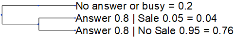

P(Sale) = 0.04

## Exercise 6.75 (10%) 說明不完整酌量扣1~2分

```python
t = Tree("((Return 0.87 | Excellent 0.57 = 0.4959, Return 0.87 | Good      0.36 = 0.3132, Return 0.87 | Fair         0.07 = 0.0609), \
        (NotReturn 0.13 | Excellent 0.14 = 0.0182, NotReturn 0.13 | Good      0.32 = 0.0416, NotReturn 0.13 | Fair         0.54 = 0.0702));" )
ts = TreeStyle()
ts.show_leaf_name = True
ts.show_scale = False
t.show(tree_style=ts)
```

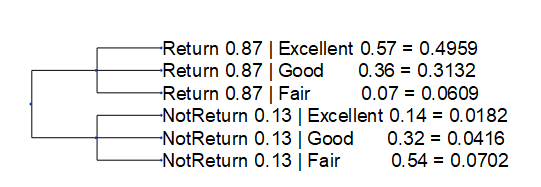

P(Good) = P(Return and Good) + P(Not Retrun and Good) = 0.3132 + 0.0416 = 0.3548

## Exercise 6.83 (10%) 說明不完整酌量扣1~2分

P(Bad) = ((# of France and Bad) + (# of Germany and Bad) + (# of Italy and Bad)) / # of all respondents = ( 630x0.62 + 590x0.74 + 480x0.57 ) / ( 630 + 590 + 480 ) = 0.6475

## Exercise 6.91 (10%) 說明不完整酌量扣1~2分

CWF: Crash with fatality

P ( CWF | BAC>0.09 ) = P ( CWF and BAC>0.09 ) / P ( BAC>0.09 ) = P ( CWF ) x P ( BAC>0.09 | CWF ) / P ( BAC>0.09 ) = 0.01x 0.084 / 0.12 = 0.007

## Exercise 6.99 (10%) 說明不完整酌量扣1~2分

```python
t = Tree("((HavingHIV 0.005 | Test Positive 0.92 = 0.0046,HavingHIV 0.005 | Test Negative 0.08 = 0.0004), \
        (NoHIV 0.995 | Test Positive 0.973 = 0.9681,NoHIV 0.995 | Test Negative 0.027 = 0.0269));" )
ts = TreeStyle()
ts.show_leaf_name = True
ts.show_scale = False
t.show(tree_style=ts)
```

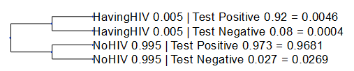